# Mineração de Dados

# Atividade 01

Professor : João Batista M. Pereira

Aluno : Marcel Quintela

O conjunto de dados a ser analisado corresponde a registros públicos de vendas de casas feitas de maio de 2014 a maio de 2015 no Condado de King, no estado de Washington, EUA.

O banco de dados está dividido em dois arquivos: kchousing1.csv e kchousing2.csv. No primeiro arquivo, as variáveis são:

- id - identifcação única da casa vendida;
- date - data da venda;
- price - preço da venda;
- bedrooms - quantidade de quartos;
- bathrooms - quantidade de banheiros, em que .5 corresponde a banheiro sem chuveiro;
- sqft living - pés quadrados do interior da casa;
- sqft lot - pés quadrados do terreno;
- floors - quantidade de andares;
- waterfront - 1, se casa é à beira-mar e 0, caso contrário;
- view - um índice de 0 a 4 indicando a qualidade da visão da propriedade;
- condition - um índice de 0 a 5 indicando a condição do apartamento;
- date2 - data da venda (\ano-mês").

No segundo arquivo as variaveis são:

- id - identificação única da casa vendida;
- date - data da venda;
- grade - um índice de 1 a 13, em que:
  - 1-3 corresponde a um baixo nível de construção e design;
  - 7 corresponde a um nível médio de construção e design e
  - 11-13 corresponde a um alto nível de construção e design
- sqft above - pés quadrados do interior da casa acima do nível do solo;
- sqft basement - pés quadrados do interior da casa abaixo do nível do solo;
- yr_built - ano em que a casa começou a ser construída;
- yr_renovated - ano da última reforma da casa;
- zipcode - código postal da casa;
- lat - latitude;
- long - longitude;
- sqft living15 - pés quadrados do interior das 15 casas mais próximas;
- sqft lot15 - pés quadrados do terreno das 15 casas mais próximas.

Orientações para cosntrução da Atividade[^1]

## Questão 01

Importe as bases de dados nos arquivos para o **R** e junte-as em um único *data frame* com todos os registros e todas as variáveis. Lembre-se que as linhas correspondem aos registros de vendas e uma casa pode ser vendida mais de uma vez.

Escolha pelo menos três variáveis do banco de dados e faça uma análise exploratória. Utilize gráficos tais como histogramas, *box-plots*, gráfico de barras e/ou gráfico de setores. Para as variáveis quantitativas, pode-se também calcular algumas medidas resumo tais como média, mediana, desvio padrão.

### Importando dados

```r
house1<-read.csv("kc_housing_1.csv",sep=",")
head(house1)
```

```
##           id            date   price bedrooms bathrooms sqft_living sqft_lot
## 1 7129300520 20141013T000000  221900        3      1.00        1180     5650
## 2 6414100192 20141209T000000  538000        3      2.25        2570     7242
## 3 5631500400 20150225T000000  180000        2      1.00         770    10000
## 4 2487200875 20141209T000000  604000        4      3.00        1960     5000
## 5 1954400510 20150218T000000  510000        3      2.00        1680     8080
## 6 7237550310 20140512T000000 1225000        4      4.50        5420   101930
##   floors waterfront view condition   date2
## 1      1          0    0         3 2014-10
## 2      2          0    0         3 2014-12
## 3      1          0    0         3 2015-02
## 4      1          0    0         5 2014-12
## 5      1          0    0         3 2015-02
## 6      1          0    0         3 2014-05
```

```r
house2<-read.csv("kc_housing_2.csv",sep=",")
head(house2)
```

```
##           id            date grade sqft_above sqft_basement yr_built
## 1 7129300520 20141013T000000     7       1180             0     1955
## 2 6414100192 20141209T000000     7       2170           400     1951
## 3 5631500400 20150225T000000     6        770             0     1933
## 4 2487200875 20141209T000000     7       1050           910     1965
## 5 1954400510 20150218T000000     8       1680             0     1987
## 6 7237550310 20140512T000000    11       3890          1530     2001
##   yr_renovated zipcode     lat     long sqft_living15 sqft_lot15
## 1            0   98178 47.5112 -122.257          1340       5650
## 2         1991   98125 47.7210 -122.319          1690       7639
## 3            0   98028 47.7379 -122.233          2720       8062
## 4            0   98136 47.5208 -122.393          1360       5000
## 5            0   98074 47.6168 -122.045          1800       7503
## 6            0   98053 47.6561 -122.005          4760     101930
```

Mesclando os dataframes importados em único dataframe usando como chave o “ID da venda” e a “data da venda”, criando assim o banco de dados das operações de venda e caracteristicas das casas.

```r
vendas<-merge(house1,house2,by=c("id","date"))
#checando os tamanhos dos data frames
dim(house1)
```

```
## [1] 21613    12
```

```r
dim(house2)
```

```
## [1] 21613    12
```

```r
dim(vendas)
```

```
## [1] 21613    22
```

```r
names(house1)
```

```
##  [1] "id"          "date"        "price"       "bedrooms"    "bathrooms"
##  [6] "sqft_living" "sqft_lot"    "floors"      "waterfront"  "view"
## [11] "condition"   "date2"
```

```r
names(house2)
```

```
##  [1] "id"            "date"          "grade"         "sqft_above"
##  [5] "sqft_basement" "yr_built"      "yr_renovated"  "zipcode"
##  [9] "lat"           "long"          "sqft_living15" "sqft_lot15"
```

```r
names(vendas)
```

```
##  [1] "id"            "date"          "price"         "bedrooms"
##  [5] "bathrooms"     "sqft_living"   "sqft_lot"      "floors"
##  [9] "waterfront"    "view"          "condition"     "date2"
## [13] "grade"         "sqft_above"    "sqft_basement" "yr_built"
## [17] "yr_renovated"  "zipcode"       "lat"           "long"
## [21] "sqft_living15" "sqft_lot15"
```

```r
head(vendas)
```

```
##           id            date  price bedrooms bathrooms sqft_living sqft_lot
## 1    1000102 20140916T000000 280000        6       3.0        2400     9373
## 2    1000102 20150422T000000 300000        6       3.0        2400     9373
## 3  100100050 20141112T000000 275000        3       1.0        1320    11090
## 4 1001200035 20150306T000000 272450        3       1.0        1350     7973
## 5 1001200050 20140923T000000 259000        4       1.5        1260     7248
## 6 1003000175 20141222T000000 221000        3       1.0         980     7606
##   floors waterfront view condition   date2 grade sqft_above sqft_basement
## 1    2.0          0    0         3 2014-09     7       2400             0
## 2    2.0          0    0         3 2015-04     7       2400             0
## 3    1.0          0    0         3 2014-11     7       1320             0
## 4    1.5          0    0         3 2015-03     7       1350             0
## 5    1.5          0    0         5 2014-09     7       1260             0
## 6    1.0          0    0         3 2014-12     7        980             0
##   yr_built yr_renovated zipcode     lat     long sqft_living15 sqft_lot15
## 1     1991            0   98002 47.3262 -122.214          2060       7316
## 2     1991            0   98002 47.3262 -122.214          2060       7316
## 3     1955            0   98155 47.7748 -122.304          1320       8319
## 4     1954            0   98188 47.4323 -122.292          1310       7491
## 5     1955            0   98188 47.4330 -122.292          1300       7732
## 6     1954            0   98188 47.4356 -122.290           980       8125
```

```r
rm(house1,house2) #Liberando memória: removendo os dados originais
```

### Análise Exploratória

```r
#Extração das variaveis de estudo
house.1<-vendas[,c(3,4,5,6,10,13)]

#Ajute das variáveis de preço
house.1$price<-house.1$price/1000

nomes<-c("Preço da Casa (x US$1.000)","Nº de Quartos", "Nº de Banheiros","Interior da Casa (ft²)","Visão da Propriedade","Nível de Construção e Design")
```

```r
#Resumos
EstDescri=function(x) { #função que retorna as resumo descritivo das variáveis
  c(NumObs    = length(x),
    Maximo    = max(x, na.rm=T),
    Minimo    = min(x, na.rm=T),
    Amplitude = max(x, na.rm=T)-min(x, na.rm=T),
    Media     = mean(x, na.rm=T),
    #Mediana   = median(x, na.rm=T),
    Q         = quantile(x,na.rm=T)[2],
    Q         = quantile(x,na.rm=T)[3],
    Q         = quantile(x,na.rm=T)[4],
    Variancia = var(x, na.rm=T),
    DesPadrao = sd(x, na.rm=T),
    CV        = 100* sd(x, na.rm=T)/mean(x, na.rm=T),
    Iqr       = IQR(x, na.rm=T), # Desvio Interquartilico
    Ass       = 3*(mean(x, na.rm=T)- median(x, na.rm=T))/sd(x, na.rm=T),
    Cur       = IQR(x, na.rm=T)/(2*(quantile(x,.90,na.rm=T)-quantile(x,.10,na.rm=T)))
  )
}

Resultados<- data.frame(EstDescri(house.1[,1]))
names(Resultados)[1]<-names(house.1)[1]

for (x in 2:length(house.1)){
  Resultados<-cbind(Resultados, EstDescri(house.1[,x]))
  names(Resultados)[x]<-names(house.1)[x]
}
names(Resultados)<-nomes

knitr::kable(Resultados,digits = 2,format.args = list(scientific = FALSE),
             caption = "Resumo descritivo das variáveis de estudo")
```

Resumo descritivo das variáveis de estudo

|  | Preço da Casa (x US$1.000) | Nº de Quartos | Nº de Banheiros | Interior da Casa (ft²) | Visão da Propriedade | Nível de Construção e Design |
| --- | --- | --- | --- | --- | --- | --- |
| NumObs | 21613.00 | 21613.00 | 21613.00 | 21613.00 | 21613.00 | 21613.00 |
| Maximo | 7700.00 | 33.00 | 8.00 | 13540.00 | 4.00 | 13.00 |
| Minimo | 75.00 | 0.00 | 0.00 | 290.00 | 0.00 | 1.00 |
| Amplitude | 7625.00 | 33.00 | 8.00 | 13250.00 | 4.00 | 12.00 |
| Media | 540.09 | 3.37 | 2.11 | 2079.90 | 0.23 | 7.66 |
| Q.25% | 321.95 | 3.00 | 1.75 | 1427.00 | 0.00 | 7.00 |
| Q.50% | 450.00 | 3.00 | 2.25 | 1910.00 | 0.00 | 7.00 |
| Q.75% | 645.00 | 4.00 | 2.50 | 2550.00 | 0.00 | 8.00 |
| Variancia | 134782.38 | 0.87 | 0.59 | 843533.68 | 0.59 | 1.38 |
| DesPadrao | 367.13 | 0.93 | 0.77 | 918.44 | 0.77 | 1.18 |
| CV | 67.98 | 27.59 | 36.42 | 44.16 | 327.06 | 15.35 |
| Iqr | 323.05 | 1.00 | 0.75 | 1123.00 | 0.00 | 1.00 |
| Ass | 0.74 | 1.20 | -0.53 | 0.55 | 0.92 | 1.68 |
| Cur.90% | 0.25 | 0.25 | 0.19 | 0.26 | NaN | 0.17 |

### Gráficos

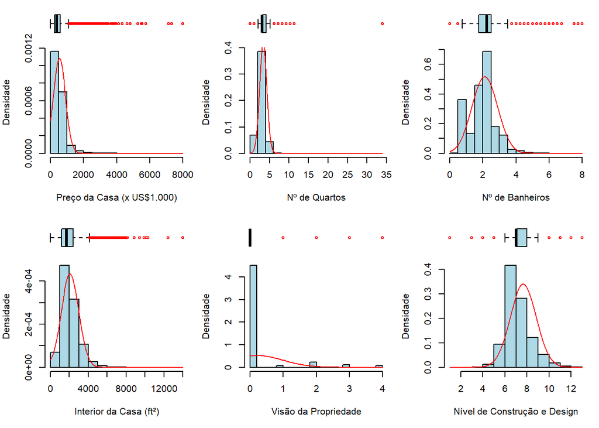

```r
#Gráficos conjugados histograma e boxplot
layout(mat = matrix(c(1:12),4,3, byrow=TRUE),  height = c(rep(c(0.2,0.7),2)))
# construção do grid de impressão 3 linhas x 4 colunas

for (i in seq(1,4,by=3)){ #linhas de impressão para cada par de gráficos

  par(mar=c(0,4, 0, 1))   #limites das margensdos box-plots
  for (i2 in i:(i+2)){    #gerando os box-plots
    boxplot(house.1[,i2],xlab=nomes[i2],col="light blue",outcol="red",
            horizontal=TRUE, xaxt="n", frame=F)
  }
  par(mar=c(5,4,0,1))     #limites das margens dos histogramas
  for(i3 in i:(i+2)){     #gerando os histogramas
    hist(house.1[,i3],xlab=nomes[i3],ylab="Densidade",
         main="",col="light blue",prob=TRUE)
    curve(dnorm(x,mean(house.1[,i3], na.rm=T),sd(house.1[,i3], na.rm=T)),add=T, col="red")
  }
}
```

o painel da combinação do histograma e box-plot, apresenta um panorama geral das variáveis selecionadas. De maneira geral, a presença de consideráveis de valores discrepantes ganha destaque. Porém, tal resumo gráfico não se mostra tão adequado para variáveis qualitativas (categóricas) como a Visão da Propriedade. É conveniente uma avaliação especifica para variáveis quantitativas e qualitativas.

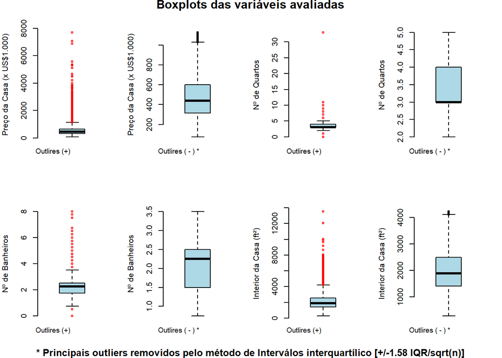

```r
# Boxplots
layout(mat = matrix(c(1:4),2,2, byrow=TRUE),  height = c(rep(c(0.2,0.7),2)))
par(mfrow=c(2,4),mar=c(4,4,3,2))

for(i in 1:(length(house.1)-2)){
  out<-boxplot.stats(house.1[,i])$out #+/- 1.58 IQR/sqrt(n)
  out_ind <- which(house.1[,i] %in% c(out))

  boxplot(house.1[,i],ylab=nomes[i],col="light blue",frame=F, outcol="red")
  mtext("Outlires (+)", side=1,line=0.5, at=0.7, cex = 0.6)

  boxplot(house.1[-out_ind,i],ylab=nomes[i],col="light blue", frame=F)
  mtext("Outlires ( - ) *", side=1,line=0.5, at=0.7, cex = 0.6)


}
par(oma=c(1,1,1.1,1),new=T,font=2,cex=0.5)
mtext(outer=TRUE,paste("Boxplots das variáveis avaliadas"),side=3)
mtext(outer=TRUE,paste("* Principais outliers removidos pelo método de Interválos interquartílico [+/-1.58 IQR/sqrt(n)]"),side=1, cex=0.8)
```

Os box-plots mostram a presença de muitas informações discrepantes, sugerindo uma avaliação mais aprofundada sobre a natureza destas com a possibilidade de remoção ou tratamento. No entanto, para este estudo, serão mantidos todos os dados originais.

```r
#Ajuste da variável visão da propriedade
house.1<-cbind(house.1,view.f=house.1$view)
house.1$view.f<-factor(house.1$view.f, levels = c("0","1","2","3","4"))

#Ajuste da variável Nível de Construção e Design
house.1<-cbind(house.1,grade.f=house.1$grade)
house.1$grade.f[(house.1$grade %in% c(1:3))]<-"Low"
house.1$grade.f[(house.1$grade %in% c(4:6))]<-"Low-Med"
house.1$grade.f[(house.1$grade==7)]<-"Med"
house.1$grade.f[(house.1$grade %in% c(8:10))]<-"Med-High"
house.1$grade.f[(house.1$grade %in% c(11:13))]<-"High"
house.1$grade.f<-factor(house.1$grade.f, levels = c("Low","Low-Med","Med","Med-High", "High"))
```

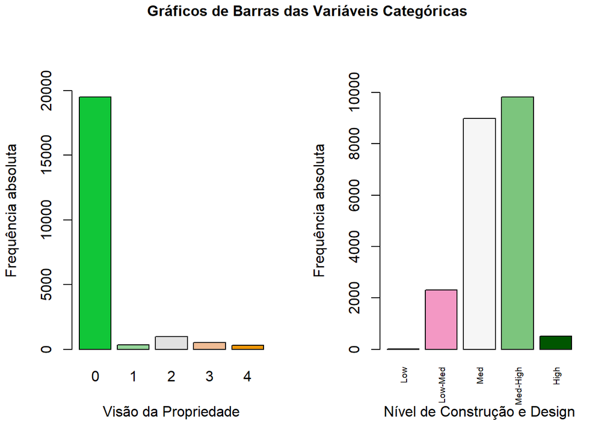

```r
#graficos das variaveis categóricas
par(mfrow = c(1,2))

x<-xtabs(~view.f,data = house.1)
barplot(x,
        ylab = "Frequência absoluta",
        xlab = nomes[5],
        ylim = c(0,max(x)*1.1),#lim sup 10% a+ p/ max para melhor visualização
        col=hcl.colors(length(x), "Green-Orange"))

x<-xtabs(~grade.f,data = house.1)
barplot(x,
        ylab = "Frequência absoluta",
        xlab = nomes[6],
        ylim = c(0,max(x)*1.1),
        col=hcl.colors(length(x), "Red-Green"),
        cex.names = 0.6,
        las=3)

par(oma=c(1,1,1.1,1),new=T,font=2,cex=0.5)
mtext(outer=TRUE,paste("Gráficos de Barras das Variáveis Categóricas"),side=3)

#gray.colors(n)
#hcl.pals() nomes das pallets
```

As variáveis categóricas mostram que a grande maioria da propriedade tem baixo nível na qualidade da visão, ao passo que o nível das construções são predominantemente consideradas como nível médio ou médio-alto.

```r
#limpando a mémoria
rm(Resultados, EstDescri,out, out_ind,x,house.1,i,i2,i3)
```

## Questão 02

Para as variáveis quantitativas, calcule a matriz de correlação e faça um gráco em que se possa facilmente visualizar as correlações entre as variáveis. Em seguida, faça diagramas de dispersão para os dois pares de variáveis mais correlacionados.

### Matriz de Correlação

```r
COR<-cor(vendas[,-c(1,2,12)])
# Kable é um gerador de tabela com formatação amigavel para saidas html
knitr::kable(COR,digits = 2,format.args = list(scientific = FALSE),
             caption = "Correlação entre as variáveis do banco de dados")
```

Correlação entre as variáveis do banco de dados

|  | price | bedrooms | bathrooms | sqft_living | sqft_lot | floors | waterfront | view | condition | grade | sqft_above | sqft_basement | yr_built | yr_renovated | zipcode | lat | long | sqft_living15 | sqft_lot15 |
| --- | --- | --- | --- | --- | --- | --- | --- | --- | --- | --- | --- | --- | --- | --- | --- | --- | --- | --- | --- |
| price | 1.00 | 0.31 | 0.53 | 0.70 | 0.09 | 0.26 | 0.27 | 0.40 | 0.04 | 0.67 | 0.61 | 0.32 | 0.05 | 0.13 | -0.05 | 0.31 | 0.02 | 0.59 | 0.08 |
| bedrooms | 0.31 | 1.00 | 0.52 | 0.58 | 0.03 | 0.18 | -0.01 | 0.08 | 0.03 | 0.36 | 0.48 | 0.30 | 0.15 | 0.02 | -0.15 | -0.01 | 0.13 | 0.39 | 0.03 |
| bathrooms | 0.53 | 0.52 | 1.00 | 0.75 | 0.09 | 0.50 | 0.06 | 0.19 | -0.12 | 0.66 | 0.69 | 0.28 | 0.51 | 0.05 | -0.20 | 0.02 | 0.22 | 0.57 | 0.09 |
| sqft_living | 0.70 | 0.58 | 0.75 | 1.00 | 0.17 | 0.35 | 0.10 | 0.28 | -0.06 | 0.76 | 0.88 | 0.44 | 0.32 | 0.06 | -0.20 | 0.05 | 0.24 | 0.76 | 0.18 |
| sqft_lot | 0.09 | 0.03 | 0.09 | 0.17 | 1.00 | -0.01 | 0.02 | 0.07 | -0.01 | 0.11 | 0.18 | 0.02 | 0.05 | 0.01 | -0.13 | -0.09 | 0.23 | 0.14 | 0.72 |
| floors | 0.26 | 0.18 | 0.50 | 0.35 | -0.01 | 1.00 | 0.02 | 0.03 | -0.26 | 0.46 | 0.52 | -0.25 | 0.49 | 0.01 | -0.06 | 0.05 | 0.13 | 0.28 | -0.01 |
| waterfront | 0.27 | -0.01 | 0.06 | 0.10 | 0.02 | 0.02 | 1.00 | 0.40 | 0.02 | 0.08 | 0.07 | 0.08 | -0.03 | 0.09 | 0.03 | -0.01 | -0.04 | 0.09 | 0.03 |
| view | 0.40 | 0.08 | 0.19 | 0.28 | 0.07 | 0.03 | 0.40 | 1.00 | 0.05 | 0.25 | 0.17 | 0.28 | -0.05 | 0.10 | 0.08 | 0.01 | -0.08 | 0.28 | 0.07 |
| condition | 0.04 | 0.03 | -0.12 | -0.06 | -0.01 | -0.26 | 0.02 | 0.05 | 1.00 | -0.14 | -0.16 | 0.17 | -0.36 | -0.06 | 0.00 | -0.01 | -0.11 | -0.09 | 0.00 |
| grade | 0.67 | 0.36 | 0.66 | 0.76 | 0.11 | 0.46 | 0.08 | 0.25 | -0.14 | 1.00 | 0.76 | 0.17 | 0.45 | 0.01 | -0.18 | 0.11 | 0.20 | 0.71 | 0.12 |
| sqft_above | 0.61 | 0.48 | 0.69 | 0.88 | 0.18 | 0.52 | 0.07 | 0.17 | -0.16 | 0.76 | 1.00 | -0.05 | 0.42 | 0.02 | -0.26 | 0.00 | 0.34 | 0.73 | 0.19 |
| sqft_basement | 0.32 | 0.30 | 0.28 | 0.44 | 0.02 | -0.25 | 0.08 | 0.28 | 0.17 | 0.17 | -0.05 | 1.00 | -0.13 | 0.07 | 0.07 | 0.11 | -0.14 | 0.20 | 0.02 |
| yr_built | 0.05 | 0.15 | 0.51 | 0.32 | 0.05 | 0.49 | -0.03 | -0.05 | -0.36 | 0.45 | 0.42 | -0.13 | 1.00 | -0.22 | -0.35 | -0.15 | 0.41 | 0.33 | 0.07 |
| yr_renovated | 0.13 | 0.02 | 0.05 | 0.06 | 0.01 | 0.01 | 0.09 | 0.10 | -0.06 | 0.01 | 0.02 | 0.07 | -0.22 | 1.00 | 0.06 | 0.03 | -0.07 | 0.00 | 0.01 |
| zipcode | -0.05 | -0.15 | -0.20 | -0.20 | -0.13 | -0.06 | 0.03 | 0.08 | 0.00 | -0.18 | -0.26 | 0.07 | -0.35 | 0.06 | 1.00 | 0.27 | -0.56 | -0.28 | -0.15 |
| lat | 0.31 | -0.01 | 0.02 | 0.05 | -0.09 | 0.05 | -0.01 | 0.01 | -0.01 | 0.11 | 0.00 | 0.11 | -0.15 | 0.03 | 0.27 | 1.00 | -0.14 | 0.05 | -0.09 |
| long | 0.02 | 0.13 | 0.22 | 0.24 | 0.23 | 0.13 | -0.04 | -0.08 | -0.11 | 0.20 | 0.34 | -0.14 | 0.41 | -0.07 | -0.56 | -0.14 | 1.00 | 0.33 | 0.25 |
| sqft_living15 | 0.59 | 0.39 | 0.57 | 0.76 | 0.14 | 0.28 | 0.09 | 0.28 | -0.09 | 0.71 | 0.73 | 0.20 | 0.33 | 0.00 | -0.28 | 0.05 | 0.33 | 1.00 | 0.18 |
| sqft_lot15 | 0.08 | 0.03 | 0.09 | 0.18 | 0.72 | -0.01 | 0.03 | 0.07 | 0.00 | 0.12 | 0.19 | 0.02 | 0.07 | 0.01 | -0.15 | -0.09 | 0.25 | 0.18 | 1.00 |

A matriz e correlação é uma ótima manaira de analizar os níveis associação linear entre pares de variáveis. Póem matizes com grandes números de váriáveis, podem não ser tão claras.

```r
#instalação de pacote necessário para ilustração da matriz de correlação
if (!require("corrplot")) install.packages("corrplot", dependencies = TRUE, INSTALL_opts = '--no-lock')
library(corrplot)
```

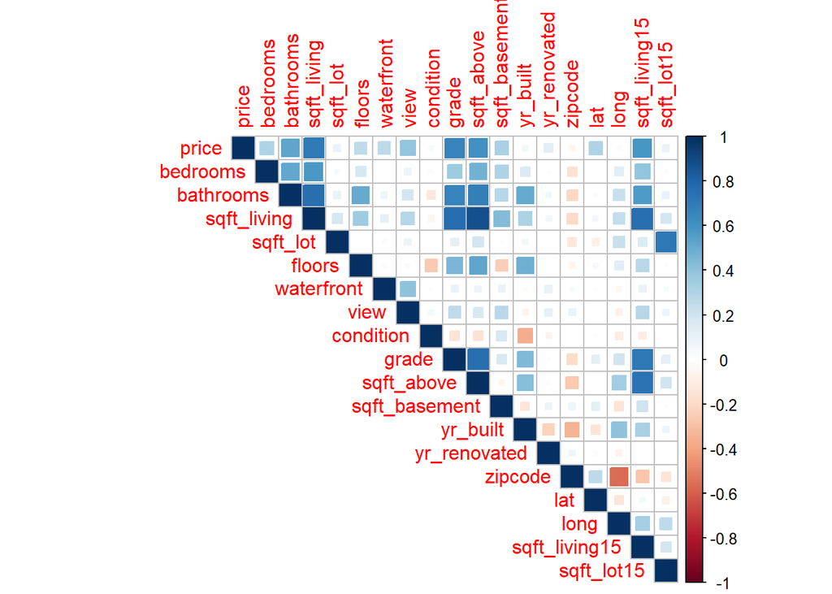

```r
#ilustração da matrix de correlações de maneira mais amigável
corrplot(COR, method = "square", type="upper")
```

```r
rm(COR)
```

### Gráficos

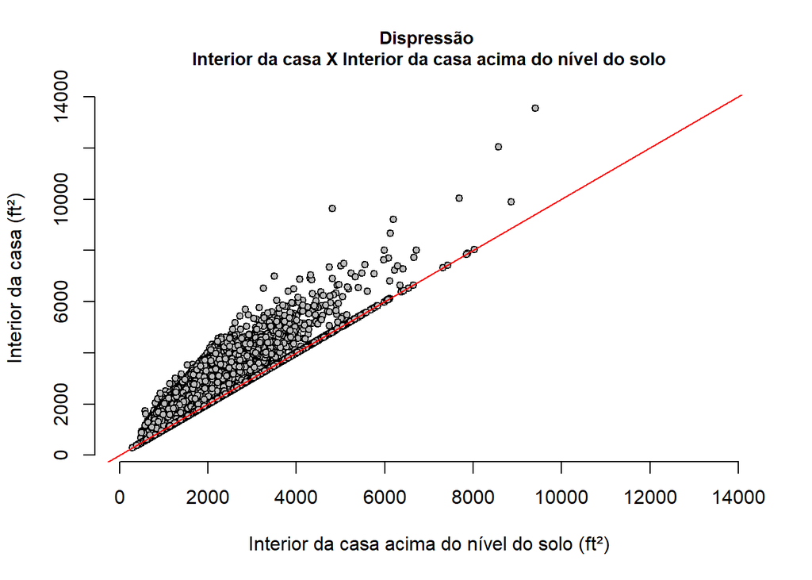

```r
# par de maior correlação
plot(sqft_living ~ sqft_above,
     data  = vendas,
     main = "Dispressão \n Interior da casa X Interior da casa acima do nível do solo ",
     cex.main = 0.9,
     xlab = "Interior da casa acima do nível do solo (ft²)",
     ylab = "Interior da casa (ft²)",
     xlim = c(0,14000),
     pch  = 21,
     cex  = 0.8,
     col  = "black",
     bg   = "gray",
     frame= FALSE)
abline(coef = c(0,1), col="red")
```

## Questão 03

Verifique grafiamente a associação entre o preço e pelo menos três outras variáveis do banco de dados. Investigue a melhor forma de visualização: gráco de dispersão, *box-blots*.

[figure not shown]

```r
#Disperssão 01
cols<-hcl.colors(length(levels(as.factor(vendas$waterfront))), "Green-Orange")

plot(price/1000 ~ sqft_living,
     data = vendas,
     main = "Preço X Interior da Casa \n (by Beira-mar)",
     xlab = "Interior da casa (ft²)",
     ylab = "Preço (US$ *1.000)",
     cex.main = 0.9,
     bg = cols,
     pch = 21,
     cex=0.8,
     frame= F)

legend("top",
       pch = 21,
       lty = 0,
       col = "black",
       pt.bg = cols,
       legend = c("Outros locais","Baira-mar"),
       bty = "n")
grid()
```

```r
rm(cols)
```

[figure not shown]

```r
#Disperssão 01
cols<-hcl.colors(length(levels(factor(vendas$condition))), "inferno")

plot(price/1000 ~ bedrooms,
     data = vendas,
     main = "Preço X Nº de Quartos \n (by Condição do Apartamento)",
     xlab = "Interior da casa (ft²)",
     ylab = "Preço (US$ *1.000)",
     cex.main = 0.9,
     bg = cols,
     pch = 21,
     cex=0.8,
     frame= F)
legend("top",
       pch = 21,
       lty = 0,
       col = "black",
       pt.bg = cols,
       legend = levels(factor(vendas$condition)),
       bty = "n")
grid()
```

```r
rm(cols)
```

### Box-Plot

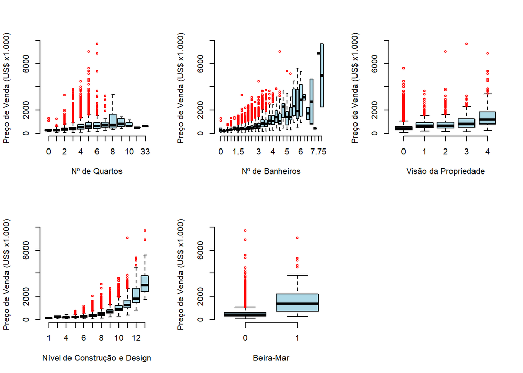

```r
x<- data.frame(Indice=c(4,5,10,13,9),Nomes=(c(nomes[c(2,3,5,6)],"Beira-Mar")))
par(mfrow = c(2,3))

for(i in 1:length(x$Indice)){
  boxplot((vendas$price/1000) ~ vendas[,x$Indice[i]],
          xlab = x$Nomes[i],
          ylab = "Preço de Venda (US$ x1.000)",
          col  = "light blue",
          frame = FALSE,
          outcol= "red")
}
rm(x)
```

## Questão 04

Agrupe os dados por data (mês e ano) e calcule a média do preço para cada mês. Em seguida, faça um gráfico de linha com a variação do preço ao longo do tempo.

A partir dos preços e pés quadrados do interior da casa, calcule, para cada registro, o preço médio do pé quadrado. Em seguida, faça um gráco de linha com a variação do preço médio ao longo do tempo.

### Preparação e Ajustes

```r
# instalação de pacotes para criação de gráfico temporal

.packages = c("dygraphs", "xts")# Lista de bibliotecas necessárias

# Instalar (caso ainda não tenha sido instalado)
.inst <- .packages %in% installed.packages()
if(length(.packages[!.inst]) > 0) install.packages(.packages[!.inst],dependencies = TRUE)

# Carregando bibliotecas
lapply(.packages, require, character.only=TRUE)
```

### Preços de Venda por Data

```r
#Arupando a média do preço de venda por date2()
x <- aggregate(vendas$price/1000, by = list(vendas$date2), FUN=mean)

#criando a sequencia de datas para auxiliar no gráfico.
x <-cbind(x,time=seq(from= as.Date("01/05/2014","%d/%m/%Y"),
                     to  = as.Date("01/05/2015","%d/%m/%Y"),
                     by  = "month"))

# Necessário trnasformar em formato "xts" para poder usar o dygraph
graf <- xts(x = x$x, order.by = x$time)

dygraph(graf,
        main="Comportamento da Média de Preços de Venda",
        ylab="Preços de Venda (US$ *1.000)",
        xlab="Meses")
```

[interactive chart not shown]

```r
rm(x,graf)
```

### Preço Médio por ft² do Interior da Casa

```r
# criando variável preço por ft² constrída
vendas <- cbind(vendas, price_ft2 = (vendas$price/vendas$sqft_living))
```

```r
#Arupando a média do preço/ft² date2()
x <- aggregate(vendas$price_ft2, by = list(vendas$date2), FUN=mean)

#criando a sequencia de datas para auxiliar no gráfico.
x <-cbind(x,time=seq(from= as.Date("01/05/2014","%d/%m/%Y"),
                     to  = as.Date("01/05/2015","%d/%m/%Y"),
                     by  = "month"))

# Necessário trnasformar em formato "xts" para poder usar o dygraph
graf <- xts(x = x$x, order.by = x$time)

dygraph(graf,
        main="Comportamento da Média de Preços/ft² do Interior da Casa",
        ylab="Preços de Venda/ft²",
        xlab="Meses")
```

[interactive chart not shown]

```r
rm(x,graf)
```

## Questão 05

Calcule os quartis do preço (valores que dividem os preços em quatro faixas, cada um com 25% dos registros). Verifique em que faixa cada preço do banco de dados se encontra e associe a ele um cor diferente. Em seguida, faça um gráco em três dimensões com a latitude, longitude e o preço (com as cores correspondentes à sua respectiva faixa).

### Preparação e Ajustes

```r
# classificação dos quartis de preços de venda
vendas<-cbind(vendas,
              price.q = with(vendas,
                             cut(price,
                                 breaks = quantile(price,
                                                   probs=seq(0,1, by=0.25),
                                                   na.rm=TRUE),
                                 labels = 1:4,
                                 include.lowest=TRUE)))
```

### Gráfico 3D Estático

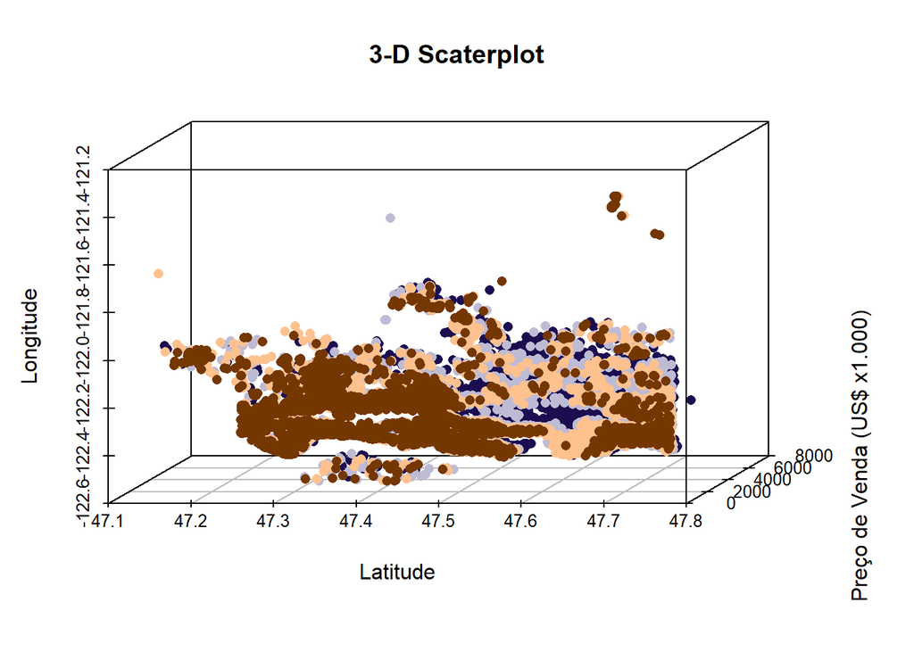

```r
#Scaterplot 3D

#Paleta de cores
cols<-hcl.colors(length(levels(vendas$price.q)), "PuOr")

with(vendas,{
  scatterplot3d(lat,price/1000,long,
                main = "3-D Scaterplot",
                xlab="Latitude",
                ylab="Preço de Venda (US$ x1.000)",
                zlab="Longitude",
                type="p",
                lty.hplot=2,
                scale.y=.5,
                box=T,
                color=cols[price.q],
                pch=16,
                angle=45)
})
```

### Gráfico 3D Interativo

```r
# Retirada de uma amostra aleatória de 1000 casas para ilustrar o grafico interativo
vendas.1<-vendas[sample(1:nrow(vendas),1000,replace=F),]

# Grafico interativo simples
# plotids <- with(vendas.1, plot3d(lat,long,(price/1000),
#  type="s", col=cols[price.q],size=1))
# rglwidget(elementId = "plot3drgl")
```

```r
#grafico interativo mais elaborado com a possibilidade de exibição dos elementos
clear3d() # Remove the earlier display

# Ciração dos elementos para o objeto grafico3d de acordo com os elementos da biblioteca rgl
Q1 <- with(subset(vendas.1, price.q == 1),
           spheres3d(lat,long,(price/1000),
                     col=cols[price.q],
                     radius = 60))

Q2 <- with(subset(vendas.1, price.q == 2),
           spheres3d(lat,long,(price/1000),
                     col=cols[price.q],
                     radius = 60))

Q3 <- with(subset(vendas.1, price.q == 3),
           spheres3d(lat,long,(price/1000),
                     col=cols[price.q],
                     radius = 60))

Q4 <- with(subset(vendas.1, price.q == 4),
           spheres3d(lat,long,(price/1000),
                     col=cols[price.q],
                     radius = 60))

#criando o objeto grafico3d, criado por plot3d ou decorate3d
axesid <- decorate3d(xlab = "Latitude", ylab = "Logitude", zlab = "Preço (x1.000)",)

#incluindo os elementos no objeto grafico3d
rglwidget() %>%
toggleWidget(ids = Q1) %>%
toggleWidget(ids = Q2) %>%
toggleWidget(ids = Q3) %>%
toggleWidget(ids = Q4) %>%
toggleWidget(ids = axesid) %>%
asRow(last = 5)
```

[interactive chart not shown]

```r
#número e objetos a serem apresentados recomendo que seja last=nº de elementos toggleWinget
#assim será apresentado em uma linha abaizo do gráfico
```

### Mapa - poins group Quatil(Price)

```r
library(leaflet)
cols<-c("orange", "lightgreen", "lightblue", "purple")

vendas.1<-cbind(vendas.1,House=paste("House ",c(1:dim(vendas.1)[1])))

printMoney <- function(x){
  format(x, digits=10, nsmall=2, decimal.mark=",", big.mark=".")
}

icone <- awesomeIcons(
  icon = 'home',
  iconColor = "white",
  library = 'ion',
  markerColor = cols[vendas.1$price.q]
)


leaflet(vendas.1) %>%
  addTiles() %>%
  addAwesomeMarkers(popup = with(vendas.1,
                          paste("<b>Preço: US$</b>",printMoney(price),"<br>",
                                "<b>Banheiros: </b>",bathrooms,"<br>",
                                "<b>Quartos: </b>",bedrooms)),
             icon=icone,
             label= ~House)
```

```
## Assuming "long" and "lat" are longitude and latitude, respectively
```

[interactive chart not shown]

### Mapa - Clusters Quartil dos Preços

```r
vendas.2<-cbind(vendas.1,
              price.qq = with(vendas.1,
                             cut(price/1000,
                                 breaks = quantile(price/1000,
                                                   probs=seq(0,1, by=0.25),
                                                   na.rm=TRUE),
                                 #labels = 1:4,
                                 include.lowest=TRUE)))

vendas.df <- split(vendas.2, vendas.2$price.qq)

l <- leaflet() %>% addTiles()

names(vendas.df) %>%
  purrr::walk( function(df) {
    l <<- l %>%
      addMarkers(data=vendas.df[[df]],
                          lng=~long, lat=~lat,
                          label=~price.q,
                          popup = with(vendas.df[[df]],
                                       paste("<b>Preço: US$</b>",printMoney(~price),"<br>",
                                        "<b>Banheiros: </b>",~bathrooms,"<br>",
                                        "<b>Quartos: </b>",~bedrooms)),
                          group = df,
                          clusterOptions = markerClusterOptions(removeOutsideVisibleBounds = F),
                          labelOptions = labelOptions(noHide = F,
                                                       direction = 'auto'))
  })

l %>%
  addLayersControl(
    overlayGroups = names(vendas.df),
    options = layersControlOptions(collapsed = FALSE)
  )
```

[interactive chart not shown]

[^1]: *A atividade deve ser feita no **R Markdown** e entregue em **HTML** ou **PDF** com os códigos explicitados e as análises comentadas. Os grácos devem ser explicativos, com nomes corretos nos eixos, por exemplo*